# Chasing the GOAT: NBA greatness Analysis (1973-2025)

Author

Sky W

Published

December 7, 2025

# 1 Introduction

The “greatest of all time” (GOAT) of NBA players has long been a debated question between fans and analysts, not just for the excitement of the game but also for understanding basketball culture and **player impact. As a basketball fan, I’ve always found it fascinating how debates about the GOAT ignite strong discussions at the lunch table. This analysis aims to** identify** the “GOAT” in NBA history using player performance data from 1973 to 2024. By combining **traditional statistics**—points, rebounds, assists, steals, blocks, turnovers, and minutes played into a **composite GOAT score**, we assess both **single-season excellence** and **career-long impact**. The project includes exploratory data analysis to see trends over decades, map-based visualizations linking **team performance** to geography, interactive dashboards for season-level visualization, and machine learning classification to determine if **age** is associated with higher GOAT scores. Through this approach, we not only highlight the GOAT players historically but also provide insights into **performance trends** and factors related to **peak achievement** in the NBA.

# 1.1 Preparation

We begin by importing our needed functions and loading the NBA Player Per Game dataset (1973–2025) and standardizing column names for consistency. To ensure fair comparisons, we exclude incomplete seasons (2026) and focus on key player statistics. Only players who participated in at least 40 games are retained to avoid inflated averages from limited playtime, and rows with missing core metrics such as minutes per game or points per game are dropped. This produces a clean, reliable dataset.

```python
import pandas as pd
import numpy as np
import matplotlib.pyplot as plt
import seaborn as sns

from sklearn.linear_model import LogisticRegression
from sklearn.model_selection import train_test_split
from sklearn.metrics import confusion_matrix, ConfusionMatrixDisplay, roc_curve, auc
```

```python
df = pd.read_csv("Player Per Game.csv")

df.columns = df.columns.str.lower().str.strip()
df = df[df["season"] < 2026]

core = df[[
    "season","player","player_id","age","team","pos","g","mp_per_game",
    "fg_per_game","fga_per_game","fg_percent",
    "x3p_per_game","x3pa_per_game","x3p_percent",
    "x2p_per_game","x2pa_per_game","x2p_percent",
    "ft_per_game","fta_per_game","ft_percent",
    "orb_per_game","drb_per_game","trb_per_game",
    "ast_per_game","stl_per_game","blk_per_game",
    "tov_per_game","pf_per_game","pts_per_game"
]]

core = core.dropna(subset=["g","mp_per_game","pts_per_game"])
core = core[core["g"] >= 40]
core.head()
```

|  | season | player | player_id | age | team | pos | g | mp_per_game | fg_per_game | fga_per_game | ... | ft_percent | orb_per_game | drb_per_game | trb_per_game | ast_per_game | stl_per_game | blk_per_game | tov_per_game | pf_per_game | pts_per_game |
| --- | --- | --- | --- | --- | --- | --- | --- | --- | --- | --- | --- | --- | --- | --- | --- | --- | --- | --- | --- | --- | --- |
| 428 | 2025 | Precious Achiuwa | achiupr01 | 25.0 | NYK | C | 57 | 20.5 | 2.9 | 5.7 | ... | 0.594 | 1.8 | 3.8 | 5.6 | 1.0 | 0.8 | 0.7 | 0.8 | 1.4 | 6.6 |
| 429 | 2025 | Steven Adams | adamsst01 | 31.0 | HOU | C | 58 | 13.7 | 1.6 | 2.9 | ... | 0.462 | 2.9 | 2.8 | 5.6 | 1.1 | 0.4 | 0.5 | 0.9 | 1.0 | 3.9 |
| 430 | 2025 | Bam Adebayo | adebaba01 | 27.0 | MIA | C | 78 | 34.3 | 6.9 | 14.3 | ... | 0.765 | 2.4 | 7.2 | 9.6 | 4.3 | 1.3 | 0.7 | 2.1 | 2.1 | 18.1 |
| 431 | 2025 | Ochai Agbaji | agbajoc01 | 24.0 | TOR | SG | 64 | 27.2 | 4.2 | 8.3 | ... | 0.708 | 1.0 | 2.8 | 3.8 | 1.5 | 0.9 | 0.5 | 0.8 | 2.0 | 10.4 |
| 432 | 2025 | Santi Aldama | aldamsa01 | 24.0 | MEM | PF | 65 | 25.5 | 4.8 | 10.0 | ... | 0.691 | 1.4 | 5.0 | 6.4 | 2.9 | 0.8 | 0.4 | 1.1 | 1.2 | 12.5 |

5 rows × 29 columns

# 2 Part 1: GOAT Score

```python
core["GOAT_score"] = (core["pts_per_game"]+ core["ast_per_game"]*1.2 + core["trb_per_game"] + core["stl_per_game"]*1.5 + core["blk_per_game"]*1.5 + core["fg_percent"]*10 - core["tov_per_game"])
top_seasons = core.sort_values("GOAT_score", ascending=False)
top_seasons.head()
```

|  | season | player | player_id | age | team | pos | g | mp_per_game | fg_per_game | fga_per_game | ... | orb_per_game | drb_per_game | trb_per_game | ast_per_game | stl_per_game | blk_per_game | tov_per_game | pf_per_game | pts_per_game | GOAT_score |
| --- | --- | --- | --- | --- | --- | --- | --- | --- | --- | --- | --- | --- | --- | --- | --- | --- | --- | --- | --- | --- | --- |
| 745 | 2025 | Nikola Jokić | jokicni01 | 29.0 | DEN | C | 70 | 36.7 | 11.2 | 19.5 | ... | 2.9 | 9.9 | 12.7 | 10.2 | 1.8 | 0.6 | 3.3 | 2.3 | 29.6 | 60.60 |
| 1334 | 2024 | Luka Dončić | doncilu01 | 24.0 | DAL | PG | 70 | 37.5 | 11.5 | 23.6 | ... | 0.8 | 8.4 | 9.2 | 9.8 | 1.4 | 0.5 | 4.0 | 2.1 | 33.9 | 58.58 |
| 21423 | 1989 | Michael Jordan | jordami01 | 25.0 | CHI | SG | 81 | 40.2 | 11.9 | 22.2 | ... | 1.8 | 6.2 | 8.0 | 8.0 | 2.9 | 0.8 | 3.6 | 3.0 | 32.5 | 57.43 |
| 21860 | 1988 | Michael Jordan | jordami01 | 24.0 | CHI | SG | 82 | 40.4 | 13.0 | 24.4 | ... | 1.7 | 3.8 | 5.5 | 5.9 | 3.2 | 1.6 | 3.1 | 3.3 | 35.0 | 57.03 |
| 6675 | 2017 | Russell Westbrook | westbru01 | 28.0 | OKC | PG | 81 | 34.6 | 10.2 | 24.0 | ... | 1.7 | 9.0 | 10.7 | 10.4 | 1.6 | 0.4 | 5.4 | 2.3 | 31.6 | 56.63 |

5 rows × 30 columns

## 2.1 Goat Score by Years

This plot shows the overall distribution of GOAT scores across all seasons from 1973 to 2025. It reveals that most player seasons cluster in the **10–30 score range**, representing typical performance levels, while the long right tail captures **exceptional, high-impact seasons**. The clear peak around **10–20** indicates the most common performance range, helping distinguish “average” seasons from truly **elite performances** which is around the score of **40-60**. Overall, the histogram highlights how rare extreme GOAT scores are compared to standard player output across NBA history.

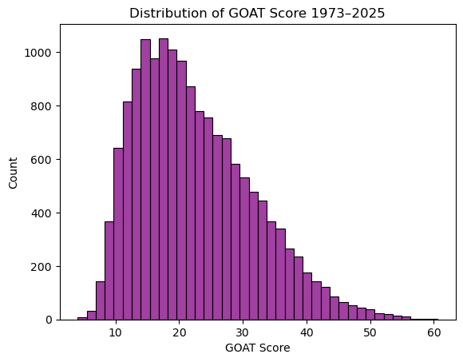

```python
plt.figure()
sns.histplot(core["GOAT_score"], bins=40, color="purple")
plt.title("Distribution of GOAT Score 1973–2025")
plt.xlabel("GOAT Score")
plt.show()
```

## 2.2 Top 5 VS Bottom 5 by GOAT Score

This chart highlights the **extremes of NBA performance** from 1973 to 2025 by showing the five seasons with the highest and lowest GOAT scores. It creates a clear visual contrast between **elite seasons** and underwhelming performances, emphasizing the wide range of individual player impact across NBA history. For examples, the top five players are **NBA legends** who are widely recognized by fans, while the bottom five consist of players that most fans have not heard of. This comparison helps highlight how the GOAT metric works, showing that it captures both extraordinary peak performances and less impactful seasons. By quantifying player contributions across multiple statistics, the metric provides a comprehensive view of **individual performance** than any single stat alone, helping distinguish legends from average seasons.

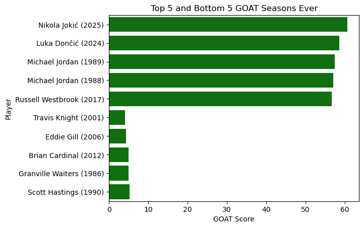

```python
top5 = core.sort_values("GOAT_score", ascending=False).head(5)
bottom5 = core.sort_values("GOAT_score", ascending=True).head(5)
extreme_seasons = pd.concat([top5, bottom5])
extreme_seasons["label"] = extreme_seasons["player"] + " (" + extreme_seasons["season"].astype(str) + ")"

plt.figure()
sns.barplot(data=extreme_seasons, y="label", x="GOAT_score", color="green", errorbar=None)
plt.title("Top 5 and Bottom 5 GOAT Seasons Ever")
plt.xlabel("GOAT Score")
plt.ylabel("Player")
plt.show()
```

## 2.3 GOAT Score Trends by Years

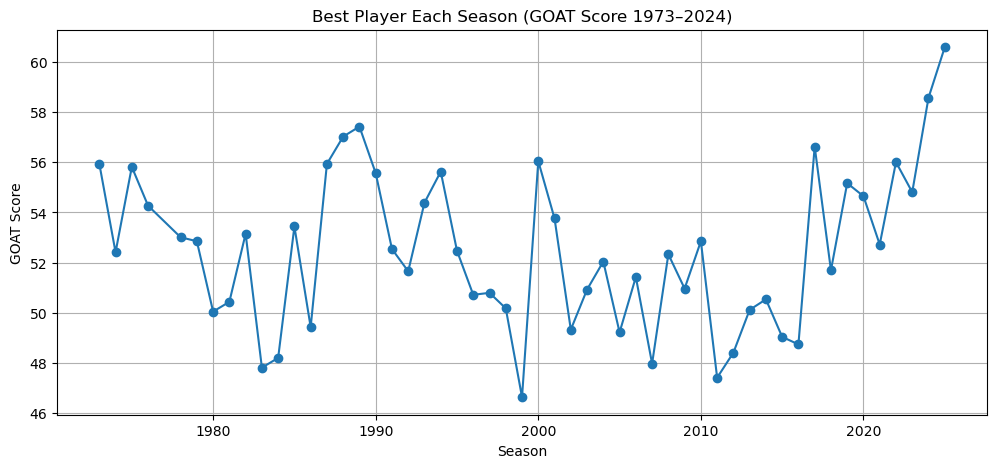

```python
core_clean = core.dropna(subset=["season", "GOAT_score"])
idx = core_clean.groupby("season")["GOAT_score"].idxmax()
season_best = core_clean.loc[idx]

plt.figure(figsize=(12,5))
plt.plot(season_best["season"], season_best["GOAT_score"], marker='o')
plt.title("Best Player Each Season (GOAT Score 1973–2024)")
plt.xlabel("Season")
plt.ylabel("GOAT Score")
plt.grid()
plt.show()
```

### 2.3.1 Interactive GOAT Score Trends by Years

```python
import plotly.graph_objects as go
top_per_season = core.loc[idx]
top_per_season_sorted = top_per_season.sort_values("season")

frames = []
for i in range(len(top_per_season_sorted)):
    frame_data = go.Scatter(x=top_per_season_sorted["season"][:i+1],
        y=top_per_season_sorted["GOAT_score"][:i+1], mode="lines+markers",
        line=dict(color="green", width=3), marker=dict(size=8, color="red"),
        hovertext=top_per_season_sorted["player"][:i+1], hoverinfo="text+x+y", name="Top GOAT Score")
    frames.append(go.Frame(data=[frame_data], name=str(i)))

fig = go.Figure(
    data=[go.Scatter(x=top_per_season_sorted["season"][:1], y=top_per_season_sorted["GOAT_score"][:1],
        mode="lines+markers", line=dict(color="green", width=3),
        marker=dict(size=8, color="red"), hovertext=top_per_season_sorted["player"][:1], hoverinfo="text+x+y")],
    layout=go.Layout(title="Top GOAT Score per Season (1973-2024)", xaxis=dict(title="Season", range=[1973, 2024]),
        yaxis=dict(title="GOAT Score", range=[top_per_season_sorted["GOAT_score"].min()-3,
                                              top_per_season_sorted["GOAT_score"].max()+3]),
        updatemenus=[dict(type="buttons", buttons=[dict(label="Play",
                          method="animate", args=[None, {"frame": {"duration": 120, "redraw": True},
                                       "fromcurrent": True, "transition": {"duration": 0}}])])]), frames=frames)

fig.update_layout(xaxis=dict(title="Season", range=[top_per_season_sorted["season"].min() -0.5,
                                                    top_per_season_sorted["season"].max() + 0.5]))

fig.show()
fig.write_html("top_per_season.html", include_plotlyjs='cdn')
```

[interactive chart not shown]

# 3 Part 2: Logistic regression

Part 2 of this analysis uses logistic regression to explore the relationship between player age and achieving a high GOAT score. By classifying players based on whether their GOAT score exceeds the median, this section looks at how age correlates with peak performance, providing insight into when players are most likely to produce elite level seasons.

## 3.1 Age correlation to GOAT score?

This logistic regression model predicts whether a player achieves a **high GOAT score** based on **age**. Using the median GOAT score as a threshold, the model classifies players into **high** and **low-performing** categories. Training on 80% of the data, the model captures trends in **peak player performance** by age, allowing us to identify if ages are associated with **top-level contributions**.

```python
age = core[['age', 'GOAT_score']].dropna().copy()

threshold = age['GOAT_score'].quantile(0.5)
age['high_goat'] = (age['GOAT_score'] >= threshold).astype(int)

X = age[['age']]
y = age['high_goat']

X_train, X_test, y_train, y_test = train_test_split(X, y, test_size=0.2, random_state=42)

model = LogisticRegression()
model.fit(X_train, y_train)

y_pred = model.predict(X_test)
probs = model.predict_proba(X_test)[:,1]
```

## 3.2 GOAT Score By Age

The confusion matrix shows that the logistic regression model performs only moderately well when using age to predict high GOAT scores. The model correctly identifies 866 low-GOAT players (**true negatives**) and 781 high-GOAT players (**true positives**). However, it also produces a large number of **false positives** = 729 and **false negatives** = 790. This indicates that while age has some predictive signal, it alone is insufficient to reliably detect elite performance, highlighting the complexity of peak basketball performance beyond just age.

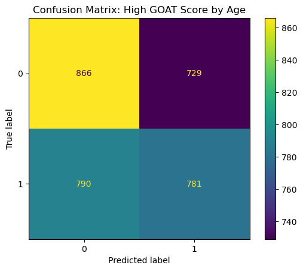

```python
cm = confusion_matrix(y_test, y_pred)
disp = ConfusionMatrixDisplay(confusion_matrix=cm)
disp.plot()
plt.title("Confusion Matrix: High GOAT Score by Age")
plt.show()
```

## 3.3 ROC Curve

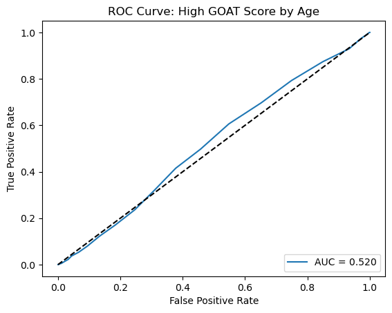

```python
fpr, tpr, _ = roc_curve(y_test, probs)
roc_auc = auc(fpr, tpr)

plt.figure()
plt.plot(fpr, tpr, label=f"AUC = {roc_auc:.3f}")
plt.plot([0,1],[0,1],'k--')
plt.title("ROC Curve: High GOAT Score by Age")
plt.xlabel("False Positive Rate")
plt.ylabel("True Positive Rate")
plt.legend(loc="lower right")
plt.show()
```

# 4 Part 3: GOAT Teams by Locations

To explore which NBA teams have historically featured the **highest-performing players**, I mapped team locations and linked them to **player GOAT scores**. Using the `team_locations` dictionary, each team was assigned latitude and longitude coordinates, creating a DataFrame suitable for visualization. This setup enables plotting metrics such as **average** or **peak GOAT score** per team, revealing which franchises have consistently produced top-performing talent throughout NBA history. The map-based perspective highlights **geographic trends** in elite player distribution and makes performance comparisons visually intuitive.

```python
team_locations = {
    "ATL": {"city": "Atlanta", "state": "GA", "lat": 33.7490, "lon": -84.3880},
    "BOS": {"city": "Boston", "state": "MA", "lat": 42.3601, "lon": -71.0589},
    "BKN": {"city": "Brooklyn", "state": "NY", "lat": 40.6501, "lon": -73.9496},
    "CHA": {"city": "Charlotte", "state": "NC", "lat": 35.2271, "lon": -80.8431},
    "CHI": {"city": "Chicago", "state": "IL", "lat": 41.8781, "lon": -87.6298},
    "CLE": {"city": "Cleveland", "state": "OH", "lat": 41.4993, "lon": -81.6944},
    "DAL": {"city": "Dallas", "state": "TX", "lat": 32.7767, "lon": -96.7970},
    "DEN": {"city": "Denver", "state": "CO", "lat": 39.7392, "lon": -104.9903},
    "DET": {"city": "Detroit", "state": "MI", "lat": 42.3314, "lon": -83.0458},
    "GSW": {"city": "San Francisco", "state": "CA", "lat": 37.7749, "lon": -122.4194},
    "HOU": {"city": "Houston", "state": "TX", "lat": 29.7604, "lon": -95.3698},
    "IND": {"city": "Indianapolis", "state": "IN", "lat": 39.7684, "lon": -86.1581},
    "LAC": {"city": "Los Angeles", "state": "CA", "lat": 33.9165, "lon": -118.3435},
    "LAL": {"city": "Los Angeles", "state": "CA", "lat": 34.0522, "lon": -118.2437},
    "MEM": {"city": "Memphis", "state": "TN", "lat": 35.1495, "lon": -90.0490},
    "MIA": {"city": "Miami", "state": "FL", "lat": 25.7617, "lon": -80.1918},
    "MIL": {"city": "Milwaukee", "state": "WI", "lat": 43.0389, "lon": -87.9065},
    "MIN": {"city": "Minneapolis", "state": "MN", "lat": 44.9778, "lon": -93.2650},
    "NOP": {"city": "New Orleans", "state": "LA", "lat": 29.9511, "lon": -90.0715},
    "NYK": {"city": "New York", "state": "NY", "lat": 40.7128, "lon": -74.0060},
    "OKC": {"city": "Oklahoma City", "state": "OK", "lat": 35.4676, "lon": -97.5164},
    "ORL": {"city": "Orlando", "state": "FL", "lat": 28.5383, "lon": -81.3792},
    "PHI": {"city": "Philadelphia", "state": "PA", "lat": 39.9526, "lon": -75.1652},
    "PHO": {"city": "Phoenix", "state": "AZ", "lat": 33.4484, "lon": -112.0740},
    "POR": {"city": "Portland", "state": "OR", "lat": 45.5152, "lon": -122.6784},
    "SAC": {"city": "Sacramento", "state": "CA", "lat": 38.5816, "lon": -121.4944},
    "SAS": {"city": "San Antonio", "state": "TX", "lat": 29.42, "lon": -98.4936},
    "TOR": {"city": "Toronto", "state": "ON", "lat": 43.6532, "lon": -79.3832},
    "UTA": {"city": "Salt Lake City", "state": "UT", "lat": 40.7608, "lon": -111.8910},
    "WAS": {"city": "Washington", "state": "DC", "lat": 38.9072, "lon": -77.0369}}

team_df = pd.DataFrame.from_dict(team_locations, orient="index").reset_index()
team_df.rename(columns={"index":"team"}, inplace=True)
```

```python
core_loc = core.merge(team_df, on="team", how="left")
core_loc = core_loc[core_loc['team'] != '2TM']
```

## 4.1 GOAT Score by Team Location

The map visualizes the **average GOAT score** for each NBA team based on player performance. Each team’s location is represented geographically, with **colorblind-friendly markers** corresponding to its mean GOAT score, allowing for easy comparison across the league. **Brighter markers** indicate teams with higher-performing players on average, highlighting **geographic trends** in team performance. For example, the **Lakers**, historically home to many legends, have an average GOAT score of 23.8, one of the highest in the league. This visualization provides an clear way to compare **team-level performance**, linking player statistics to real-world locations.

```python
import plotly.graph_objects as go
import json
import requests

state = requests.get("https://raw.githubusercontent.com/PublicaMundi/MappingAPI/master/data/geojson/us-states.json").json()

avg_goat_team = core_loc.groupby(["team","city","state","lat","lon"])["GOAT_score"].mean().reset_index()
avg_goat_team['GOAT_score'] = avg_goat_team['GOAT_score'].round(1)

fig = go.Figure()
fig.add_trace(go.Choroplethmapbox(geojson=state, locations=[s["id"] for s in state["features"]],
     z=[0]*len(state["features"]), colorscale=[[0, "lightblue"], [1, "lightblue"]],
    showscale=False, marker_line_color="white", hoverinfo="skip"))

fig.add_trace(go.Scattermapbox(lat=avg_goat_team["lat"], lon=avg_goat_team["lon"],
    mode="markers+text", text=avg_goat_team["city"], textposition="top center",
    marker=dict(size=avg_goat_team["GOAT_score"]*1, color=avg_goat_team["GOAT_score"], colorscale="Viridis", sizemode="diameter",),
    hovertemplate="<b>%{customdata[0]}</b><br>City: %{customdata[1]}<br>State: %{customdata[2]}<br>Avg GOAT Score: %{marker.size:.1f}<extra></extra>",
    customdata=avg_goat_team[["team","city","state"]]))

fig.update_layout(mapbox_style="carto-positron", mapbox_zoom=2.83,
                  mapbox_center={"lat": 37.8, "lon": -95.7}, title="Average GOAT Score by NBA Team Location",
                 width=800, height=500)

fig.show()
fig.write_html("team.html", include_plotlyjs='cdn')
```

[interactive chart not shown]

# 5 Disscussion

**LeBron James** emerges as the all-time **GOAT** when summing career GOAT scores, reflecting his **longevity** and consistently high performance—visible on the map, where his eight seasons with the **Lakers** contribute to high team averages, and on the trend graph, where he frequently led in GOAT scores from 2008–2014. In contrast, **Michael Jordan** dominates the **peak single-season rankings**, appearing twice in the top 5, highlighting his exceptional **dominance during peak years**. Additionally, **Nikola Jokić** achieved the **highest single-season GOAT score** of 60.6 in 2025, showcasing his extraordinary performance in the modern era.

```python
import plotly.express as px

top5['GOAT_score'] = top5['GOAT_score'].round(1)
top5['player_season'] = top5['player'] + " (" + top5['season'].astype(str) + ")"
top5_alltime = core.groupby('player').agg(
    total_GOAT_score=('GOAT_score', 'sum'),
    seasons_played=('season', 'count')
).reset_index().sort_values('total_GOAT_score', ascending=False).head(5)

fig1 = px.bar(top5_alltime, x='player', y='total_GOAT_score', text='total_GOAT_score',title='Top 5 All-Time GOAT Players')
fig2 = px.bar(top5, x='player_season', y='GOAT_score', text='GOAT_score', title='Top 5 Single-Season GOAT Scores')

fig1.show()
fig2.show()
```

[interactive chart not shown]

# 6 Conclusions